# Assignment 1

This assignment is meant to help you familiarize yourself with Jupyter Notebook, review Python and `numpy`, and introduce you to `matplotlib`, a Python visualization library.

To receive credit, answer all questions correctly and submit to Canvas before the deadline.

**This assignment is due Tuesday, Oct. 12 at 11:59 PM.**

**YOUR FULL NAME (1 POINT)**: *Bhagyashree Aras*

### Collaboration Policy

Data science is a collaborative activity. While you may talk with others about the assignment, we ask that you **write your solutions individually**. If you do discuss the assignments with others please **include their names** below. (That's a good way to learn your classmates' names.)

### Initialize Grader

Go to Terminal and install otter using `pip install otter-grader`

```python
# We can also install otter here
! pip install otter-grader
```

```python
# Initialize Otter
import otter
grader = otter.Notebook("A1.ipynb")
```

## Part 1: Jupyter Tips (0 points)

**NOTE: (-1) If YOU DO NOT RUN, OUTPUT, AND UNDERSTAND**

### Viewing Documentation

To output the documentation for a function, use the `help` function.

```python
help(print)
```

```
Help on built-in function print in module builtins:

print(...)
    print(value, ..., sep=' ', end='\n', file=sys.stdout, flush=False)

    Prints the values to a stream, or to sys.stdout by default.
    Optional keyword arguments:
    file:  a file-like object (stream); defaults to the current sys.stdout.
    sep:   string inserted between values, default a space.
    end:   string appended after the last value, default a newline.
    flush: whether to forcibly flush the stream.
```

```python
print('Welcome to TCSS 551.')
```

```
Welcome to TCSS 551.
```

### Importing Libraries and Magic Commands

In TCSS 551, we will be using common Python libraries to help us process data. By convention, we import all libraries at the very top of the notebook. There are also a set of standard aliases that are used to shorten the library names. Below are some of the libraries that you may encounter throughout the course, along with their respective aliases.

```python
import pandas as pd
import numpy as np
import matplotlib.pyplot as plt
plt.style.use('fivethirtyeight')
%matplotlib inline
```

`%matplotlib inline` is a [Jupyter magic command](https://ipython.readthedocs.io/en/stable/interactive/magics.html) that configures the notebook so that Matplotlib displays any plots that you draw directly in the notebook rather than to a file, allowing you to view the plots upon executing your code. (Note: In practice, this is no longer necessary, but we're showing it to you now anyway.)

Another useful magic command is `%%time`, which times the execution of that cell. You can use this by writing it as the first line of a cell. (Note that `%%` is used for *cell magic commands* that apply to the entire cell, whereas `%` is used for *line magic commands* that only apply to a single line.)

```python
%%time

lst = []
for i in range(100):
    lst.append(i)
```

```
CPU times: user 14 µs, sys: 2 µs, total: 16 µs
Wall time: 19.6 µs
```

### Keyboard Shortcuts

Even if you are familiar with Jupyter, we strongly encourage you to become proficient with keyboard shortcuts (this will save you time in the future).

Here are a few that we like:

1. `Ctrl` + `Return` (or `Cmd` + `Return` on Mac): *Evaluate the current cell*
2. `Shift` + `Return`: *Evaluate the current cell and move to the next*
3. `ESC` : *command mode* (may need to press before using any of the commands below)
4. `a` : *create a cell above*
5. `b` : *create a cell below*
6. `dd` : *delete a cell*
7. `z` : *undo the last cell operation*
8. `m` : *convert a cell to markdown*
9. `y` : *convert a cell to code*

## Part 2: Prerequisites

It's time to answer some review questions. Each question has a response cell directly below it.

If you have extra content in a response cell, such as an example call to a function you're implementing, that's fine. Also, feel free to add cells. Any extra cells you add will be considered part of your submission. Finally, when you finish an assignment, make sure to "restart and run all cells" to ensure everything works properly.

We **strongly recommend** that you check your solutions yourself using various test cases including extreme cases.

### Python

Python is the main programming language we'll use in the course. If any of the following exercises are challenging (or if you would like to refresh your Python knowledge), please review one or more of the following materials.

- **[Python Tutorial](https://docs.python.org/3.8/tutorial/)**: Introduction to Python from the creators of Python.
- **[Composing Programs Chapter 1](http://composingprograms.com/pages/11-getting-started.html)**: This is more of an introduction to programming with Python.
- **[Advanced Crash Course](http://cs231n.github.io/python-numpy-tutorial/)**: A fast crash course which assumes some programming background.

### NumPy

NumPy is the numerical computing module. Here's a quick recap of NumPy. For more review, read the following materials.

- **[NumPy Quick Start Tutorial](https://numpy.org/doc/stable/user/quickstart.html)**
- **[Stanford CS231n NumPy Tutorial](http://cs231n.github.io/python-numpy-tutorial/#numpy)**

### Simple Python Code Review (0 points)

**NOTE: (-1) IF YOU DO NOT RUN, OUTPUT, and UNDERSTAND**

You should feel confident explaining what each cell is doing. If not, please brush up using the above materials.

```python
1 + 2
```

```
3
```

```python
# This is a comment.
# In Python, the ** operator performs exponentiation.
2**4
```

```
16
```

```python
import math
math.e**(-1)
```

```
0.36787944117144233
```

```python
def add_v1(x):
    """This docstring explains what this function does: it adds 2 to a number."""
    return x + 2

add_v1(5)
```

```
7
```

```python
# add_v2 is very similar to add_v1, but it's been created using a lambda expression.
# THIS IS MORE PYTHONIC
add_v2 = lambda x: x + 2
add_v2(5)
```

```
7
```

```python
def fib(n):
    if n <= 1:
        return 1
    # Functions can call themselves recursively.
    return fib(n-1) + fib(n-2)

fib(4)
```

```
5
```

```python
# A for loop repeats a block of code once for each element in a given collection.
for i in range(5):
    if i % 2 == 0:
        print(2**i)
    else:
        print("Odd power of 2")
```

```
1
Odd power of 2
4
Odd power of 2
16
```

```python
# A list comprehension is a convenient way to apply a function
# to each element in a given collection.
# The String method join appends together all its arguments
# separated by the given string.  So we append each element produced
# by the list comprehension, each separated by a newline ("\n").
# THIS IS MORE PYTHONIC
print("\n".join([str(2**i) if i % 2 == 0 else "Odd power of 2" for i in range(5)]))
```

```
1
Odd power of 2
4
Odd power of 2
16
```

### Question 2.a (5 points)

Write a function named nums_reversed that takes in a non-negative integer *n* (extreme case: 0) and returns a string containing the numbers **1 through n** including *n* in reverse order, separated by space. For example:

nums_reversed(5)

5 4 3 2 1

nums_reversed(0)

(NOTHING TO OUTPUT)

**Bonus Point: +0.5 if you are pythonic**

```python
def nums_reversed(n):
    space = ' '
    return space.join([str(i) for i in range(1,n+1)[::-1]])
```

```python
grader.check("q02a")
```

```
Question 2.a
```

passed!

### Question 2.b (5 points)

Write a function median that takes in a list of numbers (integers or float/double numbers that can be in random order) and returns the median element of the list. If the list has even length, it returns the mean (float/double value) of the two elements in the middle. For example:

median([3, 4, 1])

3

median([2, 1, 0, 3])

1.5

median([0])

0

median([1, 2])

1.5

**HINT: YOU MAY WANT TO CHECK THE FUNCTION OF sorted()**

```python
def median(number_list):
  # type your code here
    n = len(number_list)
    number_list.sort()

    if n % 2 == 0:
        val = n//2
        median1 = number_list[val]
        median2 = number_list[val - 1]
        median = (median1 + median2)/2
    else:
        median = number_list[n//2]

    return median
```

```python
grader.check("q02b")
```

```
Question 2.b
```

passed!

## Part 3: NumPy

The core of NumPy is the array. Like Python lists, arrays store data; however, they store data in a more efficient manner. In many cases, this allows for faster computation and data manipulation.

### 3.1 Arrays

We can use `np.array` to create an array. It takes a sequence, such as a list or range.

Below, we create an array `arr` containing the values 1, 2, 3, 4, and 5 (in that order).

**NOTE: CODE EXAMPLES (0 POINTS), (-1) if you do not run, output, and understand**

```python
arr1 = np.array([1, 2, 3, 4, 5])
arr1
```

```
array([1, 2, 3, 4, 5])
```

```python
# A more generic and efficient way
arr2 = np.array(np.arange(1, 6))
arr2
```

```
array([1, 2, 3, 4, 5])
```

In addition to values in the array, we can access attributes such as shape and data type.

```python
arr1[3]
```

```
4
```

```python
arr1[2:4]
```

```
array([3, 4])
```

```python
arr1.shape
```

```
(5,)
```

```python
arr1.dtype
```

```
dtype('int64')
```

Arrays, unlike Python lists, cannot store items of different data types.

```python
# A regular Python list can store items of different data types
[1, '3']
```

```
[1, '3']
```

```python
# Arrays will convert everything to the same data type
np.array([1, '3'])
```

```
array(['1', '3'], dtype='<U21')
```

```python
# Another example of array type conversion
np.array([5, 8.3])
```

```
array([5. , 8.3])
```

Arrays are also useful in performing *vectorized operations*. Given two or more arrays of equal length, arithmetic will perform element-wise computations across the arrays.

For example, observe the following:

```python
# Python list addition will concatenate the two lists
[1, 2, 3] + [4, 5, 6]
```

```
[1, 2, 3, 4, 5, 6]
```

```python
# NumPy array addition will add them element-wise
np.array([1, 2, 3]) + np.array([4, 5, 6])
```

```
array([5, 7, 9])
```

Math operations on arrays happen element-wise as follows.

```python
arr1 * 2
```

```
array([ 2,  4,  6,  8, 10])
```

```python
arr1 * arr2
```

```
array([ 1,  4,  9, 16, 25])
```

```python
arr1 ** arr2
```

```
array([   1,    4,   27,  256, 3125])
```

This is not only very convenient (fewer for loops!) but also fast. NumPy is designed to run operations on arrays much faster than equivalent Python code on lists. Data Science sometimes involves working with large datasets where speed is important - even the constant factors!

#### More Guidelines

**NOTE: 0 POINTS. -5 IF YOU DO NOT ENTER YOUR ANSWER, RUN, AND OUTPUT**

Data science is a rapidly expanding field and no degree program can hope to teach you everything that will be helpful to you as a data scientist. So it's important that you become familiar with looking up documentation and learning how to read it.

Below is a section of code that plots a three-dimensional "wireframe" plot. You'll see what that means when you draw it. Replace each `# Your answer here` with a description of what the line above does, what the arguments being passed in are, and how the arguments are used in the function. For example,

```
np.arange(2, 5, 0.2)
# This returns an array of numbers from 2 to 5 with an interval size of 0.2
```

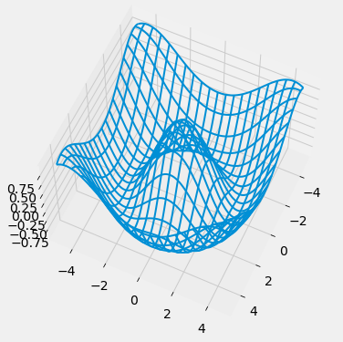

```python
from mpl_toolkits.mplot3d import axes3d

u = np.linspace(1.5 * np.pi, -1.5 * np.pi, 100)
# returns an ndarray with equally spaced intervals between the start and stop values
[x, y] = np.meshgrid(u, u)
# return coordinate matrices from coordinate vectors.
squared = np.sqrt(x.flatten() ** 2 + y.flatten() ** 2)
z = np.cos(squared)
# calculate trigonometric cosine for given value
z = z.reshape(x.shape)
# give a new shape to an array without changing its data.

fig = plt.figure(figsize = (6, 6))
ax = fig.add_subplot(111, projection = '3d')
# add an axes to the figure as part of a subplot arrangement
ax.plot_wireframe(x, y, z, rstride = 5, cstride = 5, lw = 2)
# takes a grid of values and projects onto the 3d surfaces
ax.view_init(elev = 60, azim = 25)
# set the elevation and azimuth of the axes. It can be used to rotate the axes.
plt.savefig("figure1.png")
# save the figure created after plotting data
```

#### Question 3.1.a (5 points)

Using the `np.linspace` function, create an array called xs that contains 100 evenly spaced points between `0` and `2*np.pi`. Then, create an array called ys that contains the value of `sin(x)` at each of those 100 points of xs.

HINT: Use the np.sin function. You should be able to define each variable (i.e., xs and ys) with one line of code.

```python
# define xs and ys here
# type your code here
xs = np.linspace(0, 2 * np.pi, 100)
ys = np.sin(xs)
```

```python
grader.check('q0301a')
```

```
Question 3.1.a
```

passed!

Here, we give an example how we can use matplotlib to plot our sin wave defined above. Specifically, it makes a scatter plot of the (x, y) pairs and connects points with line segments. If you give it enough points, it will appear to create a smooth curve.

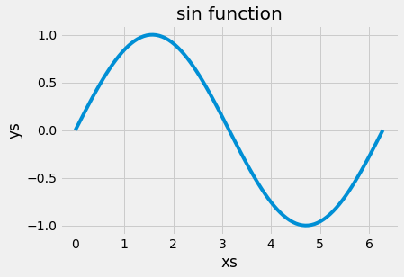

```python
plt.plot(xs, ys)

# Add communication information for your plot
plt.title('sin function')
plt.xlabel('xs')
plt.ylabel('ys')
```

#### Question 3.1.b (5 points)

Write a function `elementwise_array_sum` that computes the square of each value in `list_1`, the cube of each value in `list_2`, then returns a list containing the element-wise sum of these results. Assume that `list_1` and `list_2` have the same number of elements.

The input parameters will both be **python lists**, so you may need to convert the lists into arrays before performing your operations. The output should be a **numpy array.**

**Note**: You should not use `for` loops in your solution (if so, 0 point). Check the [NumPy documentation](https://numpy.org/doc/1.18/reference/index.html). If you're stuck, try a search engine! Searching the web for examples of how to use modules is very common in data science.

```python
def elementwise_array_sum(list_1, list_2):
    """Compute x^2 + y^3 for each x, y in list_1, list_2.

    Assume list_1 and list_2 have the same length.

    Return a NumPy array.
    """
    assert len(list_1) == len(list_2), "both args must have the same number of elements"
    # type your code here
    list_1 = np.power(list_1, 2)
    list_2 = np.power(list_2, 3)
    list = np.add(list_1, list_2)
    return list
```

```python
grader.check('q0301b')
```

```
Question 3.1.b
```

passed!

You might have been told that Python is slow, but array arithmetic is carried out very fast, even for large arrays. Below is an implementation of the above code that does not use NumPy arrays.

**NOTE: 0 points for the following guideline code, -1 if you do not run, output and understand.**

```python
def elementwise_list_sum(list_1, list_2):
    """Compute x^2 + y^3 for each x, y in list_1, list_2.

    Assume list_1 and list_2 have the same length.
    """

    return [x ** 2 + y ** 3 for x, y in zip(list_1, list_2)]
```

For ten numbers, `elementwise_list_sum` and `elementwise_array_sum` both take a similar amount of time.

```python
sample_list_1 = list(range(10))
sample_array_1 = np.arange(10)
```

```python
%%time
elementwise_list_sum(sample_list_1, sample_list_1)
```

```
CPU times: user 11 µs, sys: 1 µs, total: 12 µs
Wall time: 16.2 µs
```

```
[0, 2, 12, 36, 80, 150, 252, 392, 576, 810]
```

```python
%%time
elementwise_array_sum(sample_array_1, sample_array_1)
```

```
CPU times: user 34 µs, sys: 5 µs, total: 39 µs
Wall time: 41.7 µs
```

```
array([  0,   2,  12,  36,  80, 150, 252, 392, 576, 810])
```

The time difference seems negligible for a list/array of size 10; depending on your setup, you may even observe that `elementwise_list_sum` executes faster than `elementwise_array_sum`! However, we will commonly be working with much larger datasets:

```python
sample_list_2 = list(range(100000))
sample_array_2 = np.arange(100000)
```

```python
%%time
elementwise_list_sum(sample_list_2, sample_list_2)
# The semicolon hides the output
;
```

```
CPU times: user 54.8 ms, sys: 5.9 ms, total: 60.7 ms
Wall time: 60 ms
```

```
''
```

```python
%%time
elementwise_array_sum(sample_array_2, sample_array_2)
;
```

```
CPU times: user 761 µs, sys: 2.02 ms, total: 2.78 ms
Wall time: 1.87 ms
```

```
''
```

With the larger dataset, we see that using NumPy results in code that executes way faster! Throughout this course (and in the real world), you will find that writing efficient code will be important; arrays and vectorized operations are the most common way of making Python programs run quickly.

### 3.2 Multidimensional Arrays

A multidimensional array is a primitive version of a table, containing only one kind of data and having no column labels. A 2-dimensional array is useful for working with matrices of numbers.

**NOTE: 0 points for guidelines, -1 if you do not run, output and understand**

```python
# The zeros function creates an array with the given shape.
# For a 2-dimensional array like this one, the first
# coordinate says how far the array goes *down*, and the
# second says how far it goes *right*.
arr3 = np.zeros((4, 5))
arr3
```

```
array([[0., 0., 0., 0., 0.],
       [0., 0., 0., 0., 0.],
       [0., 0., 0., 0., 0.],
       [0., 0., 0., 0., 0.]])
```

```python
# The shape attribute returns the dimensions of the array.
arr3.shape
```

```
(4, 5)
```

```python
# You can think of array3 as an array containing 4 arrays, each
# containing 5 zeros.  Accordingly, we can set or get the third
# element of the second array in array 3 using standard Python
# array indexing syntax twice:
arr3[1][2] = 7
arr3
```

```
array([[0., 0., 0., 0., 0.],
       [0., 0., 7., 0., 0.],
       [0., 0., 0., 0., 0.],
       [0., 0., 0., 0., 0.]])
```

```python
# This comes up so often that there is special syntax provided
# for it.  The comma syntax is equivalent to using multiple
# brackets:
arr3[1, 2] = 8
arr3
```

```
array([[0., 0., 0., 0., 0.],
       [0., 0., 8., 0., 0.],
       [0., 0., 0., 0., 0.],
       [0., 0., 0., 0., 0.]])
```

Arrays allow you to assign to multiple places at once. The special character : means "everything".

```python
arr4 = np.zeros((3, 5))
arr4[:, 2] = 5
arr4
```

```
array([[0., 0., 5., 0., 0.],
       [0., 0., 5., 0., 0.],
       [0., 0., 5., 0., 0.]])
```

In fact, you can use arrays of indices to assign to multiple places. Study the next example and make sure you understand how it works.

```python
arr5 = np.zeros((3, 5))
rows = np.array([1, 0, 2])
cols = np.array([3, 1, 4])

# Indices (1,3), (0,1), and (2,4) will be set.
arr5[rows, cols] = 3
arr5
```

```
array([[0., 3., 0., 0., 0.],
       [0., 0., 0., 3., 0.],
       [0., 0., 0., 0., 3.]])
```

#### Question 3.2.a (5 points)

Create a 50x50 array called twice_identity that contains all zeros except on the diagonal, where it contains the value 2.

Start by making a 50x50 array of all zeros, then set the values. **Use indexing, not a for loop! (Don't use np.eye either, though you might find that function useful later. Don't use np.diag_indices or np.fill_diagonal)**

```python
# type your code here
...
twice_identity= np.zeros((50, 50))
list = []
start, end = 0, 50
list.extend(range(start, end))
rows = np.array(list)
cols = np.array(list)
twice_identity[rows,cols] = 2
```

```python
grader.check('q0302a')
```

```
Question 3.2.a
```

passed!

To double-check your work, the cell below will rerun all of the autograder tests.

```python
grader.check_all()
```

```
Question 2.a results: All test cases passed!

Question 2.b results: All test cases passed!

Question 3.1.a results: All test cases passed!

Question 3.1.b results: All test cases passed!

Question 3.2.a results: All test cases passed!
```

## Submission

Make sure you have run all cells in your notebook in order, so that all images/graphs appear in the output.

1. Export as html
2. Download ipynb
3. Submit both to Canvas (NOT zip)